# Comparative proteomics of lethal and non-pathogenic Ebolavirus species envelope glycoproteins

**A Critical Domain of Ebolavirus Envelope Glycoprotein Determines Glycoform and Infectivity** by Fujihira et al, 2018 (https://www.nature.com/articles/s41598-018-23357-8) identifies a small stretch of surface glycoprotein amino acids (amino acids 33-50) that play a significant role in the glycoprotein’s ability to infect cells in vitro. They found differences in this stretch between Zaire ebolavirus and Reston ebolavirus. Using an in vitro system and the glycoprotein’s known receptor, they found that Reston ebolavirus became more infectious when this stretch of it’s glycoprotein was replaced with that of Zaire ebolavirus.

We chose to recapitulate this seqeuence alignment and analyze the amino acid differences.

```r
# Loading libraries

library(Biostrings)
library(tidyverse)
library(pwalign)
library(ggthemes)
library(ggplot2)
library(dplyr)
library(ggmsa)
library(ggseqlogo)
```

## Sequence alignment

Using a stretch of amino acid (AA) sequences from AA 30 to 60, spanning AA 33-50 AA 33-50 has been identified as playing a role in infectivity

```r
# Read in sequences from txt files
# Zaire GP
zgp <- AAString(readLines(file.choose())) # Choose zgp_30_60.txt
print(zgp)
```

```
30-letter AAString object
seq: TFSIPLGVIHNSTLQVSDVDKLVCRDKLSS
```

```r
# Reston GP
rgp <- AAString(readLines(file.choose())) # Choose rgp_30_60.txt
print(rgp)
```

```
30-letter AAString object
seq: AISMPLGIVTNSTLKATEIDQLVCRDKLSS
```

```r
# Align sequences using pairwise alignment
alignment_GP <- pairwiseAlignment(pattern = zgp, subject = rgp)
print(alignment_GP)
```

```
Global PairwiseAlignmentsSingleSubject (1 of 1)
pattern: TFSIPLGVIHNSTLQVSDVDKLVCRDKLSS
subject: AISMPLGIVTNSTLKATEIDQLVCRDKLSS
score: 2.597545
```

```r
# Extract sequences (with ziare as pattern and reston as subject) and convert to character vector
# Character vector will store strings of text
aligned_pattern <- as.character(alignment_GP@pattern)
aligned_subject <- as.character(alignment_GP@subject)

# Create alignment matrix
# Splits into single characters
# 2 rows, one for each sequence
# byrow = TRUE --> data filled by row
alignment_matrix <- matrix(c(strsplit(aligned_pattern, "")[[1]],
                             strsplit(aligned_subject, "")[[1]]),
                           nrow = 2, byrow = TRUE)


# Labels rows, or sequences, as below
rownames(alignment_matrix) <- c("Zaire", "Reston")
```

## ggmsa visualization

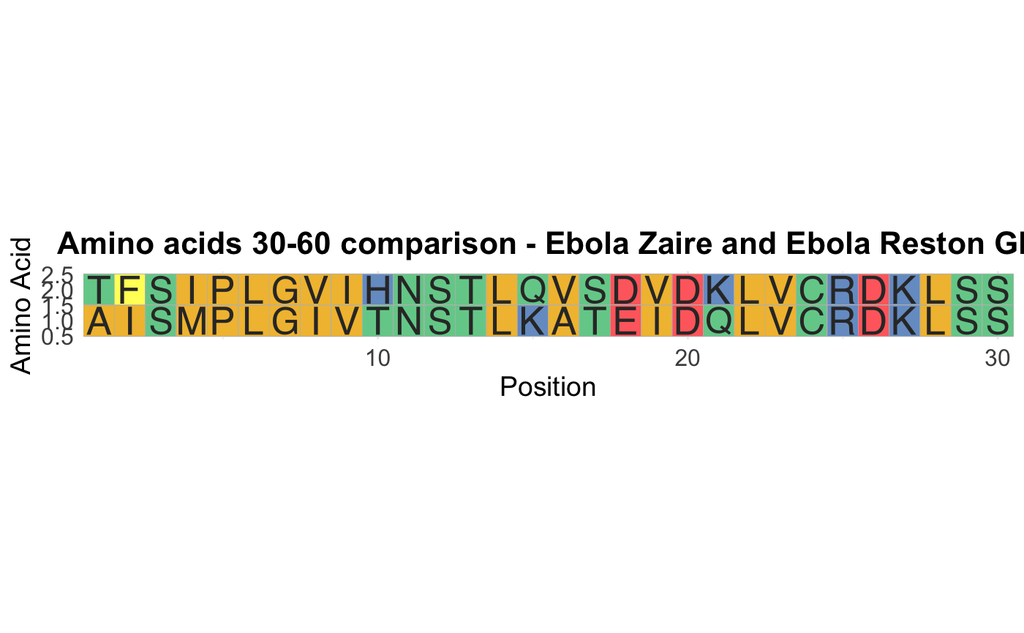

```r
plot(ggmsa)
```

## ggseqlogo visualization

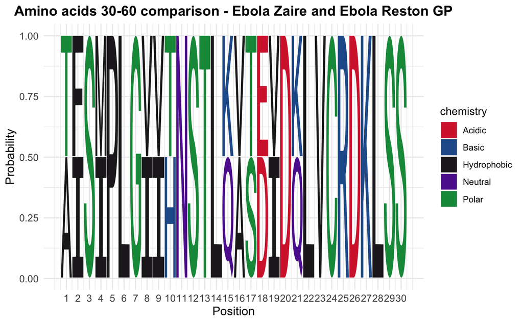

## Create a substitution table and visualize frequency amino acid changes

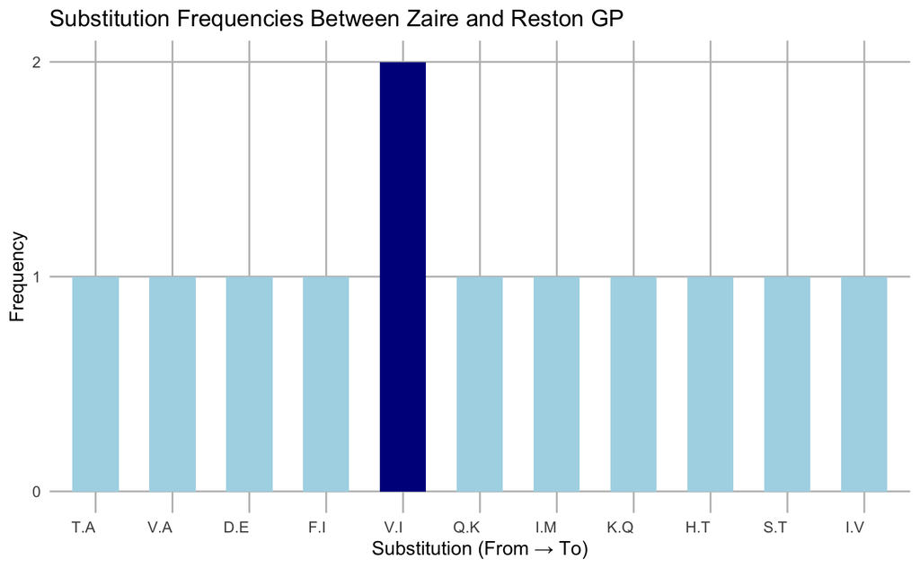

```r
# Create data frame for table
substitution_table <- data.frame(From = character(0),
                                 To = character(0),
                                 Frequency = integer(0),
                                 stringsAsFactors = FALSE)

# Loop through alignment to compare amino acids and see if any have changed
for (i in 1:nchar(aligned_pattern)) {
  aa1 <- substr(aligned_pattern, i, i)  # Amino acid from Zaire sequence (pattern)
  aa2 <- substr(aligned_subject, i, i)  # Amino acid from Reston sequence (subject)

  if (aa1 != aa2) {  # Tracks changes, not matches, where aa1 does not equal aa2
    # Add the substitution to the table (From -> To)
    substitution_table <- rbind(substitution_table, # Fills substitution table
                                data.frame(From = aa1,
                                           To = aa2,
                                           Frequency = 1))
  }
}

# Calculates frequency of each substitution and puts into table format
substitution_table <- substitution_table %>%
  group_by(From, To) %>%
  summarise(Frequency = sum(Frequency)) %>%
  arrange(desc(Frequency))
#view(substitution_table)


# Plot substitution table
sub_table <- ggplot(substitution_table, aes(x = interaction(From, To), y = Frequency, fill = Frequency)) +
  geom_bar(stat = "identity", show.legend = FALSE, width = 0.6) +
  scale_fill_gradient(low = "lightblue", high = "darkblue") +
  scale_y_continuous(breaks = seq(0, max(substitution_table$Frequency), by = 1)) +
  theme_minimal() +
  labs(x = "Substitution (From → To)",
       y = "Frequency",
       title = "Substitution Frequencies Between Zaire and Reston GP") +
  theme(axis.text.x = element_text(hjust = 1),
        panel.grid.major = element_line(color = "gray", size = 0.5),
        panel.grid.minor = element_blank()
  )

plot(sub_table)
ggsave("substitution_table.png", plot = sub_table, width = 10, height = 5, dpi = 300)
```

## Find alignment percent identity

```r
# Assigns matches as 0
matches <- 0
total_positions <- nchar(aligned_pattern)

# Loops through each position in alignment and checks for matches
for (i in 1:total_positions) {
  aa1 <- substr(aligned_pattern, i, i)  # Zaire sequence
  aa2 <- substr(aligned_subject, i, i)  # Reston sequence

  if (aa1 == aa2) {  # Check if the amino acids are the same
    matches <- matches + 1 # If match, add to matches
  }
}

# Percent identity calculation
percent_identity <- (matches / total_positions) * 100

# Print
cat("Percent Identity between Zaire and Reston GP: ", percent_identity, "%\n")
```

```
Percent Identity between Zaire and Reston GP:  60 %
```

## Looking at amino acid properties

This will look at single changes at a time, meaning we can go from our substitution table and ask this block to look at specific changes and the nature of them. For example, if we want to investigate V –> I, which shows up twice above, we can do this below.

```r
# Define properties for each amino acid
# This was taken from a list provided by ChatGPT, not generated by us
aa_properties <- data.frame(
  Amino_Acid = c("A", "C", "D", "E", "F", "G", "H", "I", "K", "L", "M", "N", "P", "Q", "R", "S", "T", "V", "W", "Y"),
  Charge = c("Neutral", "Neutral", "Acidic", "Acidic", "Neutral", "Neutral", "Basic", "Neutral", "Basic", "Neutral", "Neutral", "Polar", "Neutral", "Polar", "Basic", "Neutral", "Neutral", "Neutral", "Neutral", "Neutral"),
  Size = c("Small", "Small", "Medium", "Medium", "Large", "Small", "Medium", "Large", "Large", "Large", "Medium", "Small", "Small", "Small", "Large", "Small", "Small", "Small", "Large", "Large"),
  Hydrophobicity = c("Hydrophobic", "Hydrophobic", "Hydrophilic", "Hydrophilic", "Hydrophobic", "Hydrophobic", "Hydrophilic", "Hydrophobic", "Hydrophilic", "Hydrophobic", "Hydrophobic", "Hydrophilic", "Hydrophobic", "Hydrophilic", "Hydrophilic", "Hydrophilic", "Hydrophilic", "Hydrophobic", "Hydrophobic", "Hydrophobic")
)

# Most frequent amino acid substitution (V --> I)
from_aa <- "V"
to_aa <- "I"

# Get properties for the substitution
from_properties <- aa_properties[aa_properties$Amino_Acid == from_aa, ]
to_properties <- aa_properties[aa_properties$Amino_Acid == to_aa, ]

# Print the properties of both amino acids
cat("From:", from_aa, "Properties:", paste(from_properties[2:4], collapse = ", "), "\n")
```

```
From: V Properties: Neutral, Small, Hydrophobic
```

```r
cat("To:", to_aa, "Properties:", paste(to_properties[2:4], collapse = ", "), "\n")
```

```
To: I Properties: Neutral, Large, Hydrophobic
```

```r
#Later on,
#For more detailed functional analysis or to understand if an amino acid change could affect protein activity (e.g., enzyme activity, binding affinity, etc.), there are databases and tools that can be used, such as:
#SIFT (Sorting Intolerant From Tolerant): Predicts whether an amino acid substitution affects protein function based on sequence conservation.
#PolyPhen-2 (Polymorphism Phenotyping v2): Predicts the impact of amino acid substitutions on protein function.
#PROVEAN: Another tool that predicts the functional effects of amino acid substitutions on protein function.
#There are R packages to interface with some of these tools and databases, or you can use external tools and import the results into R for further analysis.

# Idea: chemistry changes - are they similar or very different
# Idea: number of changes compared to whole sequence compared
```